# Práctica 3

Javier Cano

5 de noviembre de 2016

# Actividad 1

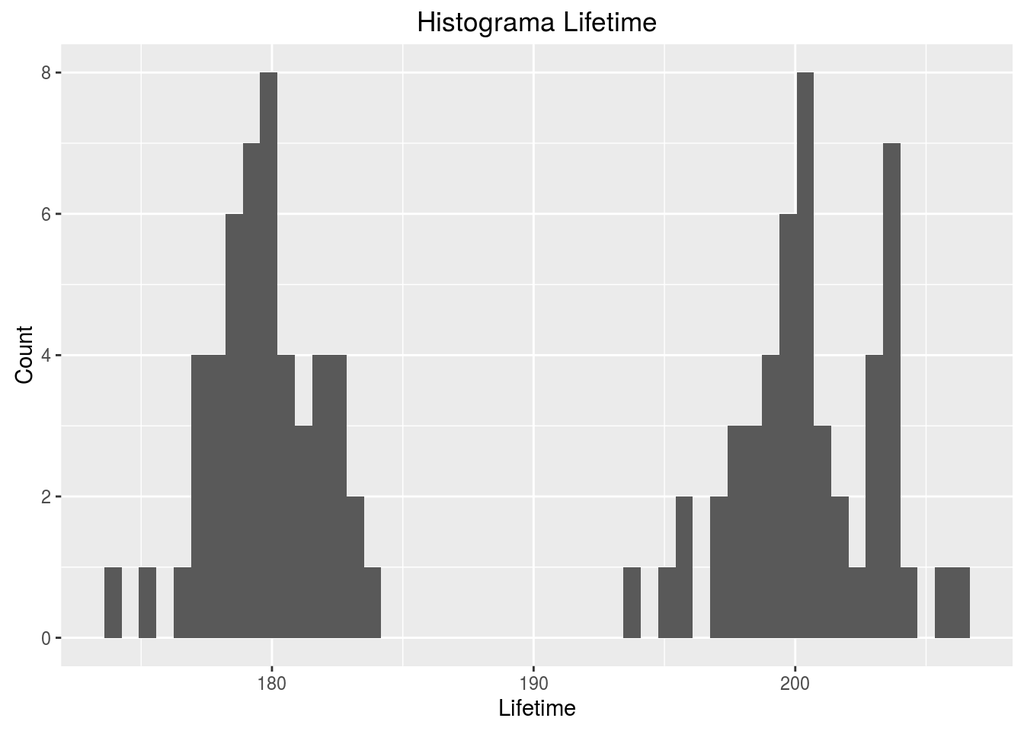

```r
ggplot(datos, aes(datos$lifetime)) +
  geom_histogram(bins=50) +
  labs(x="Lifetime", y="Count", title="Histograma Lifetime")
```

Como se puede observar en el histograma, se observan una distribución bimodal. A continuación representaremos los datos con colores para comprobar si interesa separarlos.

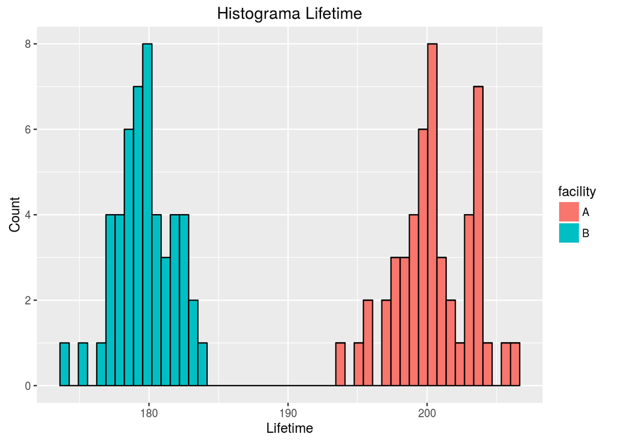

```r
ggplot(datos,aes(datos$lifetime)) +
  geom_histogram(aes(fill = facility, col = I("black")),bins = 50) +
  labs(x="Lifetime", y="Count", title="Histograma Lifetime")
```

Como se observa en el segundo histograma, cada una de las modas pertenece a un fabricante distinto, por lo que sí es recomendable separar los datos.

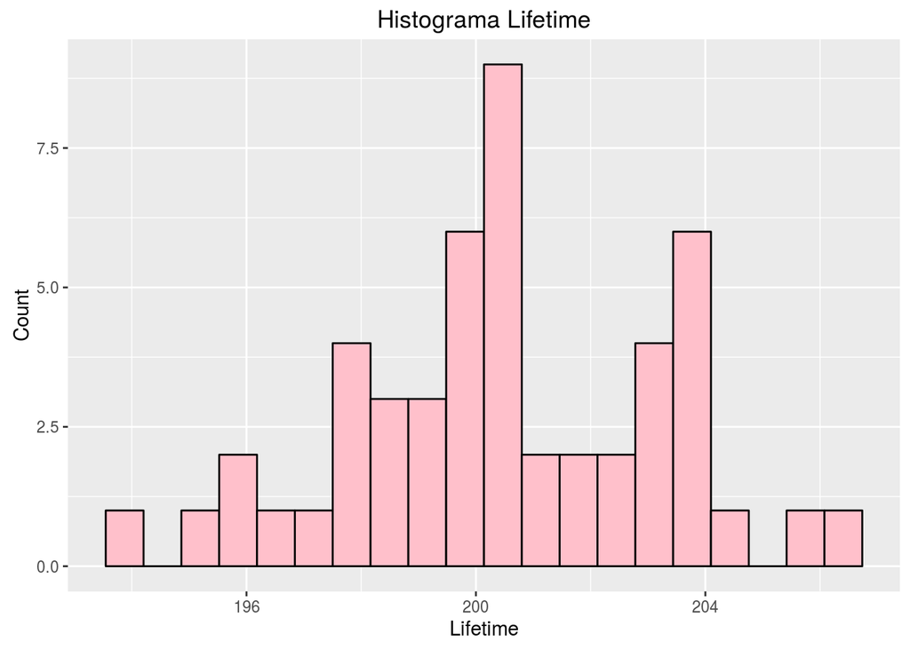

```r
datos_a <- filter(datos,facility=="A")
datos_b <- filter(datos,facility=="B")

ggplot(datos_a,aes(datos_a$lifetime)) +
  geom_histogram(fill = "pink", col = I("black"),bins = 20) +
  labs(x="Lifetime", y="Count", title="Histograma Lifetime")
```

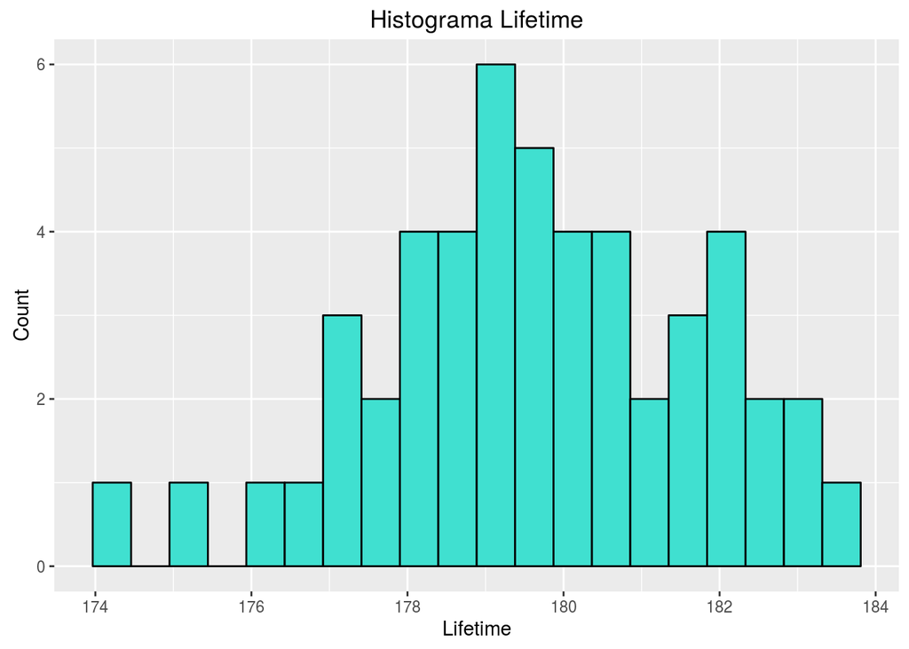

```r
ggplot(datos_b,aes(datos_b$lifetime)) +
  geom_histogram(fill = "turquoise", col = I("black"),bins = 20) +
  labs(x="Lifetime", y="Count", title="Histograma Lifetime")
```

A simple vista, parece que ambos tipos de batería siguen una distribución normal. Vamos a comprobarlo con gráficos QQ y correlaciones.

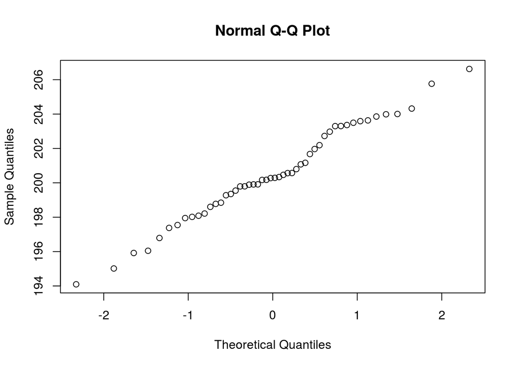

```r
qq_a <- qqnorm(datos_a$lifetime)
```

```r
cor(qq_a$x,qq_a$y)
```

```
## [1] 0.9929148
```

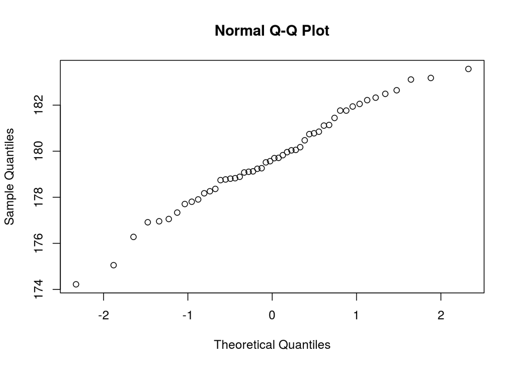

```r
qq_b <- qqnorm(datos_b$lifetime)
```

```r
cor(qq_b$x,qq_b$y)
```

```
## [1] 0.9927717
```

Como se puede observar en los gráficos y las correlaciones, la escala probabilística está dispuesta como una línea cercana a la recta, por lo que se puede afirmar que ambos tipos de batería siguen una distribución normal.

# Actividad 2

Estimaremos la media y desviación típica de cada tipo de batería.

```r
# Ya que hemos terminado con los gráficos descartamos $facility y
# nos quedamos exclusivamente con $lifetime para simplificar el resto del código.
datos_a <- datos_a$lifetime
datos_b <- datos_b$lifetime

mean_a <- mean(datos_a)
sd_a <- sd(datos_a)
mean_b <- mean(datos_b)
sd_b <- sd(datos_b)

mean_a; sd_a;
```

```
## [1] 200.5087
```

```
## [1] 2.745777
```

```r
mean_b; sd_b
```

```
## [1] 179.6805
```

```
## [1] 2.084977
```

La probabilidad de que una batería al azar del tipo A dure más de 210 horas es:

```r
pnorm(210,mean_a,sd_a,lower.tail = F)
```

```
## [1] 0.0002734129
```

La probabilidad de que una batería al azar del tipo B dure menos de 175 horas es:

```r
p_175_b <- pnorm(175,mean_b,sd_b)
p_175_b
```

```
## [1] 0.01238792
```

La duración máxima del 3% que dura menos de la baterías del tipo B:

```r
qnorm(0.03,mean_b,sd_b)
```

```
## [1] 175.7591
```

# Actividad 3

La probabilidad de que en un lote de 10 baterías del tipo B no haya defectuosas:

```r
dbinom(0,10,p_175_b)
```

```
## [1] 0.8828033
```

La probabilidad de que la quinta batería sea la primera defectuosa:

```r
dgeom(4,p_175_b)
```

```
## [1] 0.01178539
```

La probabilidad de que, en una caja de 20 baterías con 3 defectuosas, haya 1 defectuosa al tomar 5 sin reposición.

```r
dhyper(1,5,20-5,3)
```

```
## [1] 0.4605263
```

# Actividad 4

```r
n_b <- 1000
```

Probabilidad de que se produzcan más de 20 baterías defectuosas, para una media de 12:

```r
ppois(20,12,F)
```

```
## [1] 0.01159774
```

Probabilidad de que no haya baterías defectuosas:

```r
ppois(0,12)
```

```
## [1] 6.144212e-06
```

La distribución de las baterías defectuosas a lo largo de la semana:

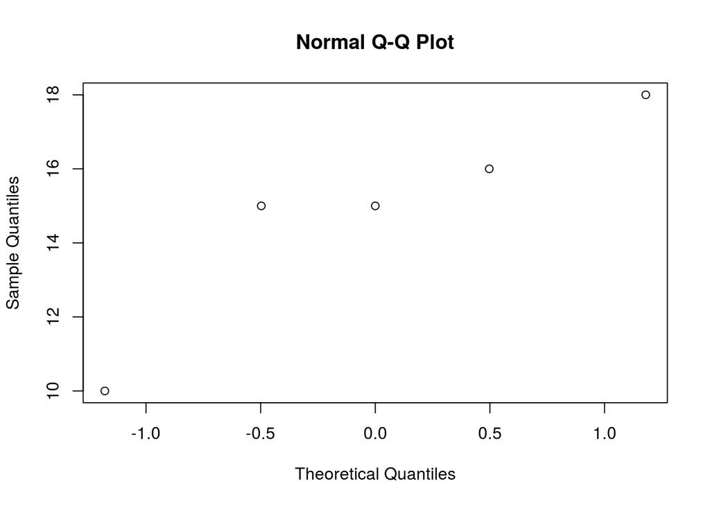

```r
set.seed(100)
# Generamos 5000 baterías
semana_p <- rpois(5*n_b,p_175_b)
# Para calcular la distribución a lo largo de la semana,
# separamos los días en un vector y sumamos las baterías defectuosas diarias
dias <- vector()
for(i in 1:5)
  dias[i] <- sum(semana_p[n_b*i-1:n_b*i])
# Comprobamos que la distribución es normal y si tiene correlación
dist_semana <- qqnorm(dias)
```

```r
cor(dist_semana$x,dist_semana$y)
```

```
## [1] 0.9302089
```

Como se observa en el gráfico QQ y la correlación, la distribución de las baterías defectuosas se ajusta a la normal.

# Actividad 5

Realizamos la simulación con los nuevos materiales que ajustan la fabricación a una distribución Weibull:

```r
# Generamos 5000 baterías
total_semana_w <- rweibull(5*n_b,100,185)
# Nos quedamos con las defectuosas
semana_w <- total_semana_w[which(total_semana_w<175)]
```

Comprobemos si el nuevo proceso mejora la duración de las baterías. Con el proceso anterior, se generaban las siguientes baterías defectuosas a la semana:

```r
sum(semana_p)
```

```
## [1] 79
```

Con el nuevo proceso, las baterías defectuosas por semana son:

```r
length(semana_w)
```

```
## [1] 22
```

Por tanto, teniendo en cuenta que el proceso anterior tenía una probabilidad

```r
p_175_b
```

```
## [1] 0.01238792
```

de crear una batería defectuosa y el nuevo proceso

```r
length(semana_w)/(5*n_b)
```

```
## [1] 0.0044
```

sí que merece la pena aplicar el nuevo proceso.